# Création de cartes choroplèthes avec ggplot2

# Solutions

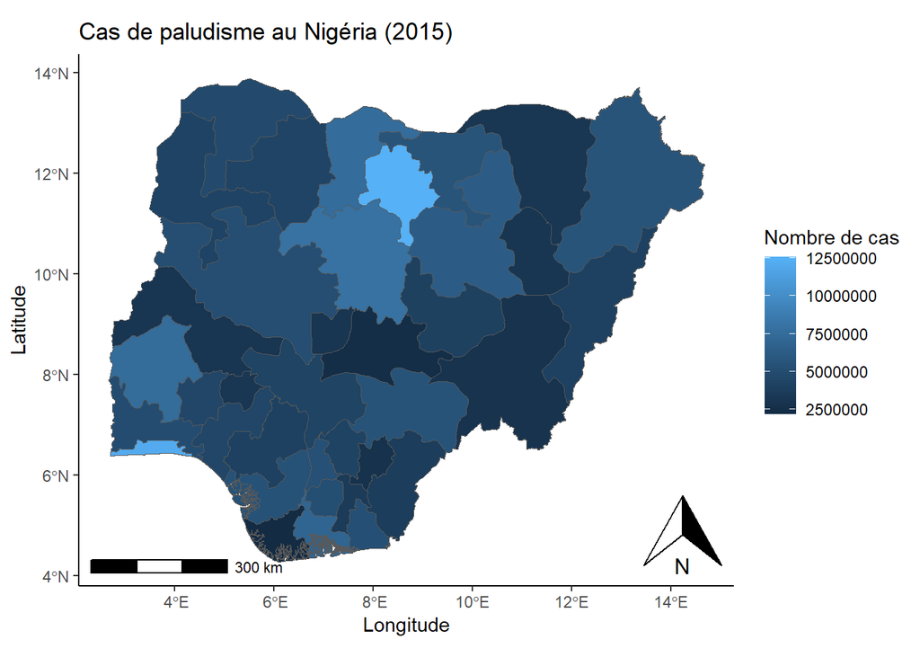

```r
ggplot(data=malaria2) +
  geom_sf(aes(fill=cases_2015)) +
  labs(title = "Cas de paludisme au Nigéria (2015)",
       fill = "Nombre de cas",
       x = "Longitude",
       y = "Latitude") +
  ggspatial::annotation_north_arrow(location = "br")+
  ggspatial::annotation_scale(location = "bl")+
  theme_classic()
```

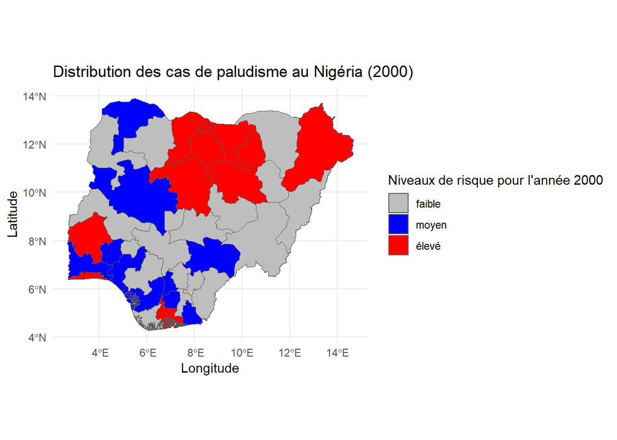

```r
new_palette <- c("grey", "blue", "red") # Définissez un ensemble de couleurs différent
ggplot(data=malaria3) +
   geom_sf(aes(fill = fct_reorder(risk, cases_2000))) + # Réorganisez les étiquettes de risque en fonction des cas de l'année 2000
   scale_fill_manual(values = new_palette, "Niveaux de risque pour l'année 2000") +
   labs(title = "Distribution des cas de paludisme au Nigéria (2000)",
        fill = "Nombre de cas",
        x = "Longitude",
        y = "Latitude") +
   coord_sf(expand = TRUE)+
   theme_minimal()
```

3. Pour catégoriser les données en fonction de la médiane au lieu des quantiles, nous devons apporter une petite modification à la fonction `mutate()` où se produit la catégorisation du risque. Plus précisément, au lieu d’utiliser la fonction des quantiles, nous utiliserons la fonction de la médiane pour calculer la médiane des cas et diviser les données en risques “faibles” et “élevés” en fonction de cette valeur.

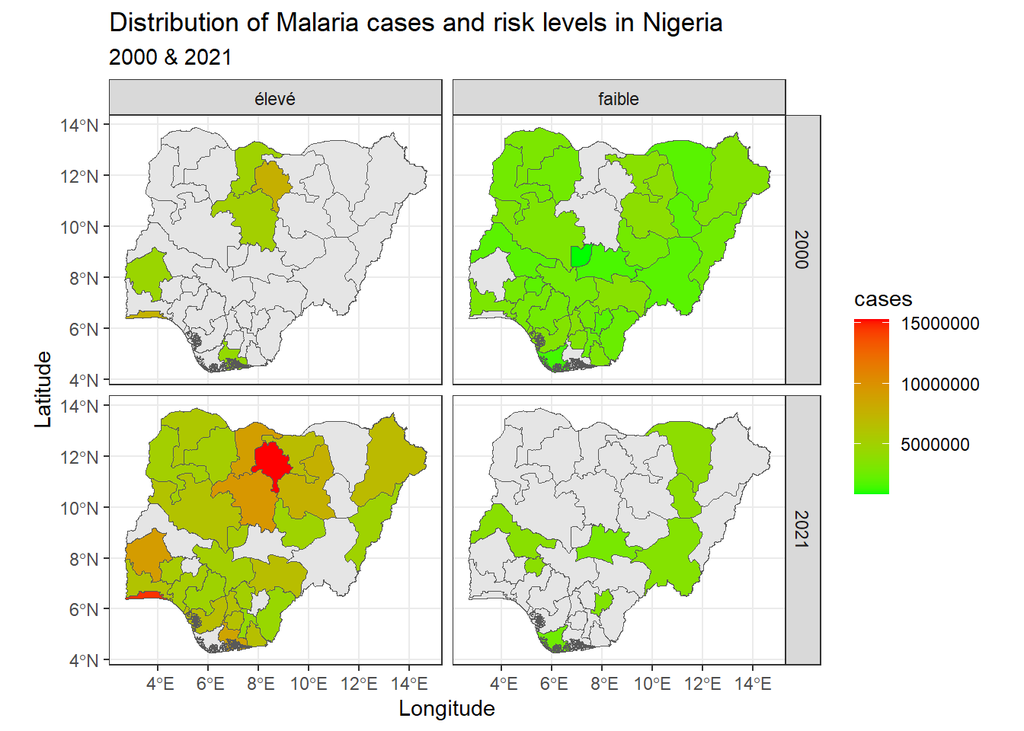

```r
# Pivoter les données
malaria3_longer <- malaria2 %>%
  pivot_longer(cols = `cases_2000`:`cases_2021`, names_to = "year", values_to = "cases")

# Catégoriser le risque en fonction de la médiane
malaria3_longer %>%
  mutate(risk = case_when(
    cases <= median(cases) ~ 'faible',
    cases > median(cases) ~ 'élevé'
  )) -> malaria3_longer2

# Nettoyer les valeurs de l'année
malaria3_longer2$year <- str_replace(malaria3_longer2$year, "cases_", "")

# Tracer les données
ggplot() +
  geom_sf(data = nga_adm1) +
  geom_sf(aes(fill = cases), data = filter(malaria3_longer2, year %in% c("2000", "2021"))) +
  facet_grid(year ~ risk) +
  coord_sf(expand = TRUE) +
  scale_fill_continuous(low = "green", high = "red") +
  labs(title = "Distribution of Malaria cases and risk levels in Nigeria",
       subtitle = "2000 & 2021") +
  xlab("Longitude") +
  ylab("Latitude") +
  theme_bw()
```

# Contributeurs

Les membres de l’équipe suivants ont contribué à cette leçon :

- [IMAD EL BADISY](https://thegraphcourses.org/members/ielbadisy/)  
  Data Science Education Officer

  Deeply interested in health data
- [JOY VAZ](https://thegraphcourses.org/members/joy)  
  R Developer and Instructor, the GRAPH Network

  Loves doing science and teaching science

# Références

1. Hadley Wickham. *ggplot2: Elegant Graphics for Data Analysis (3e).* Available at: https://ggplot2-book.org/
2. Hadley Wickham and Garrett Grolemund. *R for Data Science.* Available at: https://r4ds.had.co.nz/
3. Robin Lovelace, Jakub Nowosad, and Jannes Muenchow. *Geocomputation with R.* Available at: https://r.geocompx.org/

This work is licensed under the [Creative Commons Attribution Share Alike](https://creativecommons.org/licenses/by-sa/4.0/) license.